# Has July ever been this hot before?

2026-07-15

## Question

Has July ever been this hot before, and what has hot July meant for overall seasonal (Jul-Sep) rainfall?

## Analysis frame

- *July heat* is measured two ways:
  1. July 1-15 mean daily maximum temperature, to compare the current month-to-date heat fairly against past Julys at the same point in the month.
  2. Full-month July mean daily maximum temperature, to test whether a hot July has historically meant a wetter or drier Jul-Sep season.
- *Seasonal rainfall* means total rain in July-September of the same year.
- Data source is the local ERA5 archive only.

## Data prep

```r
temp_hourly <- blrTemp %>%
  transmute(
    DT = as_datetime(DT),
    date = as_date(DT),
    year = year(DT),
    month = month(DT),
    day = day(DT),
    temp_c = as.numeric(Temp)
  ) %>%
  filter(!is.na(temp_c))

rain_hourly <- blrRain %>%
  transmute(
    DT = as_datetime(DT),
    date = as_date(DT),
    year = year(DT),
    month = month(DT),
    day = day(DT),
    rain_mm = as.numeric(Rain)
  ) %>%
  filter(!is.na(rain_mm))

daily_weather <- temp_hourly %>%
  summarise(
    tmin = min(temp_c, na.rm = TRUE),
    tmax = max(temp_c, na.rm = TRUE),
    tmean = mean(temp_c, na.rm = TRUE),
    .by = c(date, year, month, day)
  ) %>%
  left_join(
    rain_hourly %>%
      summarise(rain_mm = sum(rain_mm, na.rm = TRUE), .by = c(date, year, month, day)),
    by = c("date", "year", "month", "day")
  ) %>%
  filter(is.finite(tmin), is.finite(tmax), !is.na(rain_mm))

daily_weather %>%
  summarise(
    first_date = min(date),
    last_date = max(date),
    days = n(),
    years = n_distinct(year)
  )
```

```
##   first_date  last_date  days years
## 1 1981-01-01 2026-07-15 16632    46
```

## July so far: is this already an unusually hot July?

```r
july_ytd <- daily_weather %>%
  filter(month == 7, day <= cutoff_day) %>%
  summarise(
    mean_tmax = mean(tmax),
    mean_tmin = mean(tmin),
    mean_tmean = mean(tmean),
    days_30 = sum(tmax >= 30),
    days_31 = sum(tmax >= 31),
    days_32 = sum(tmax >= 32),
    days_33 = sum(tmax >= 33),
    days_35 = sum(tmax >= 35),
    max_tmax = max(tmax),
    rain_total = sum(rain_mm),
    rainy_days = sum(rain_mm > 0.1),
    .by = year
  ) %>%
  mutate(
    rank_mean_tmax = min_rank(desc(mean_tmax)),
    rank_max_tmax = min_rank(desc(max_tmax)),
    rank_days_33 = min_rank(desc(days_33))
  )

current_ytd <- july_ytd %>% filter(year == current_year)
current_ytd
```

```
##   year mean_tmax mean_tmin mean_tmean days_30 days_31 days_32 days_33 days_35
## 1 2026    28.772  21.55733   24.76722       4       4       3       1       0
##   max_tmax rain_total rainy_days rank_mean_tmax rank_max_tmax rank_days_33
## 1    33.05      37.22         11              4             1            1
```

```r
thresholds_ytd <- july_ytd %>%
  summarise(
    across(c(days_30, days_31, days_32, days_33, days_35), list(mean = mean, max = max))
  )

thresholds_ytd
```

```
##   days_30_mean days_30_max days_31_mean days_31_max days_32_mean days_32_max
## 1    0.7391304           4    0.1521739           4   0.06521739           3
##   days_33_mean days_33_max days_35_mean days_35_max
## 1   0.02173913           1            0           0
```

```r
july_ytd %>%
  arrange(desc(mean_tmax)) %>%
  select(year, mean_tmax, mean_tmin, days_30, days_31, days_32, days_33, days_35, max_tmax, rain_total) %>%
  slice(1:8)
```

```
##   year mean_tmax mean_tmin days_30 days_31 days_32 days_33 days_35 max_tmax
## 1 2015  29.26333  21.28733       3       0       0       0       0    30.53
## 2 2019  29.06400  21.76133       4       0       0       0       0    30.08
## 3 2002  28.99000  20.83267       0       0       0       0       0    29.82
## 4 2026  28.77200  21.55733       4       4       3       1       0    33.05
## 5 1996  28.65200  20.33400       2       0       0       0       0    30.62
## 6 1986  28.51267  20.47600       1       0       0       0       0    30.15
## 7 1982  28.50600  19.98467       2       0       0       0       0    30.63
## 8 1999  28.44667  20.08867       0       0       0       0       0    29.98
##   rain_total
## 1      22.64
## 2      58.72
## 3      17.51
## 4      37.22
## 5      60.07
## 6      21.11
## 7      30.67
## 8      21.14
```

The current July is **hot, but not the hottest July 1-15 in the archive**. It ranks fourth on mean daily maximum temperature over the first 15 days. What is more extreme is the *single-day* heat: the hottest day so far is the hottest July 1-15 day in the archive, and there is already one day at or above 33°C.

```r
current_ytd %>%
  transmute(
    year,
    mean_tmax = round(mean_tmax, 2),
    mean_tmin = round(mean_tmin, 2),
    max_tmax = round(max_tmax, 2),
    days_30, days_31, days_32, days_33, days_35,
    rain_total = round(rain_total, 2),
    rainy_days,
    rank_mean_tmax,
    rank_max_tmax,
    rank_days_33
  )
```

```
##   year mean_tmax mean_tmin max_tmax days_30 days_31 days_32 days_33 days_35
## 1 2026     28.77     21.56    33.05       4       4       3       1       0
##   rain_total rainy_days rank_mean_tmax rank_max_tmax rank_days_33
## 1      37.22         11              4             1            1
```

## Chart 1: July 1-15 heat through time

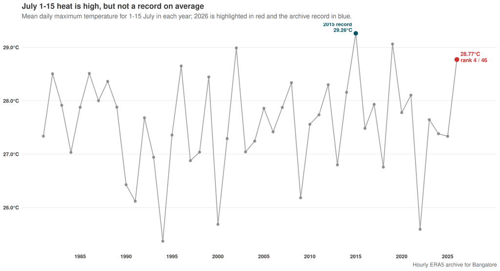

```r
ytd_plot_data <- july_ytd %>%
  mutate(
    label = if_else(year == current_year, paste0(year, "  ", round(mean_tmax, 2), "°C"), NA_character_)
  )

record_ytd <- july_ytd %>% arrange(desc(mean_tmax)) %>% slice(1)

p_ytd <- ggplot(ytd_plot_data, aes(year, mean_tmax)) +
  geom_line(color = "#7a7a7a", linewidth = 0.7, alpha = 0.65) +
  geom_point(color = "#7a7a7a", size = 1.7, alpha = 0.75) +
  geom_point(data = current_ytd, color = "#CD3333", size = 3.2) +
  geom_point(data = record_ytd, color = "#005566", size = 2.9) +
  geom_text(
    data = current_ytd,
    aes(label = paste0(round(mean_tmax, 2), "°C\nrank ", fmt_rank(rank_mean_tmax, nrow(july_ytd)))),
    hjust = -0.02,
    nudge_x = 0.35,
    vjust = 0.25,
    size = 3.3,
    fontface = "bold",
    color = "#CD3333",
    lineheight = 0.95
  ) +
  geom_text(
    data = record_ytd,
    aes(label = paste0(year, " record\n", round(mean_tmax, 2), "°C")),
    hjust = 1.02,
    nudge_x = -0.35,
    vjust = -0.15,
    size = 3.1,
    fontface = "bold",
    color = "#005566",
    lineheight = 0.95
  ) +
  scale_x_continuous(breaks = seq(1985, 2025, 5), limits = c(1981, 2028)) +
  scale_y_continuous(labels = label_number(accuracy = 0.1, suffix = "°C")) +
  labs(
    title = "July 1-15 heat is high, but not a record on average",
    subtitle = "Mean daily maximum temperature for 1-15 July in each year; 2026 is highlighted in red and the archive record in blue.",
    caption = "Hourly ERA5 archive for Bangalore"
  ) +
  theme_weather_question()

p_ytd
```

```r
chart_ytd_path <- file.path(chart_dir, "july_hot_rainfall_ytd_heat.png")
ggsave(chart_ytd_path, p_ytd, width = 12, height = 6.5, dpi = 180, bg = "white")
```

## What does a hot July mean for Jul-Sep rainfall?

This is the historical full-July test. I use complete Julys from 1981-2025, then compare them with the total rainfall in July-September of the same year.

```r
july_full <- daily_weather %>%
  filter(month == 7, year <= current_year - 1) %>%
  summarise(
    mean_tmax = mean(tmax),
    mean_tmin = mean(tmin),
    mean_tmean = mean(tmean),
    days_30 = sum(tmax >= 30),
    days_31 = sum(tmax >= 31),
    days_32 = sum(tmax >= 32),
    days_33 = sum(tmax >= 33),
    days_35 = sum(tmax >= 35),
    max_tmax = max(tmax),
    .by = year
  )

jas_rain <- daily_weather %>%
  filter(month %in% 7:9, year <= current_year - 1) %>%
  summarise(jas_rain_mm = sum(rain_mm), .by = year)

july_full <- july_full %>%
  left_join(jas_rain, by = "year") %>%
  mutate(heat_quartile = ntile(mean_tmax, 4))

cor_heat_rain <- cor(july_full$mean_tmax, july_full$jas_rain_mm, use = "complete.obs")
spearman_heat_rain <- cor(july_full$mean_tmax, july_full$jas_rain_mm, use = "complete.obs", method = "spearman")

list(
  pearson = cor_heat_rain,
  spearman = spearman_heat_rain
)
```

```
## $pearson
## [1] -0.03719574
##
## $spearman
## [1] -0.02450593
```

```r
july_full %>%
  group_by(heat_quartile) %>%
  summarise(
    n = n(),
    mean_heat = mean(mean_tmax),
    mean_jas_rain = mean(jas_rain_mm),
    median_jas_rain = median(jas_rain_mm),
    min_jas_rain = min(jas_rain_mm),
    max_jas_rain = max(jas_rain_mm),
    .groups = "drop"
  ) %>%
  mutate(
    mean_heat = round(mean_heat, 2),
    mean_jas_rain = round(mean_jas_rain, 1),
    median_jas_rain = round(median_jas_rain, 1),
    min_jas_rain = round(min_jas_rain, 1),
    max_jas_rain = round(max_jas_rain, 1)
  )
```

```
## # A tibble: 4 × 7
##   heat_quartile     n mean_heat mean_jas_rain median_jas_rain min_jas_rain
##           <int> <int>     <dbl>         <dbl>           <dbl>        <dbl>
## 1             1    12      26.5          403.            413.         223
## 2             2    11      27.1          376.            354.         238.
## 3             3    11      27.3          383             347.         210.
## 4             4    11      28.2          393.            389.         233.
## # ℹ 1 more variable: max_jas_rain <dbl>
```

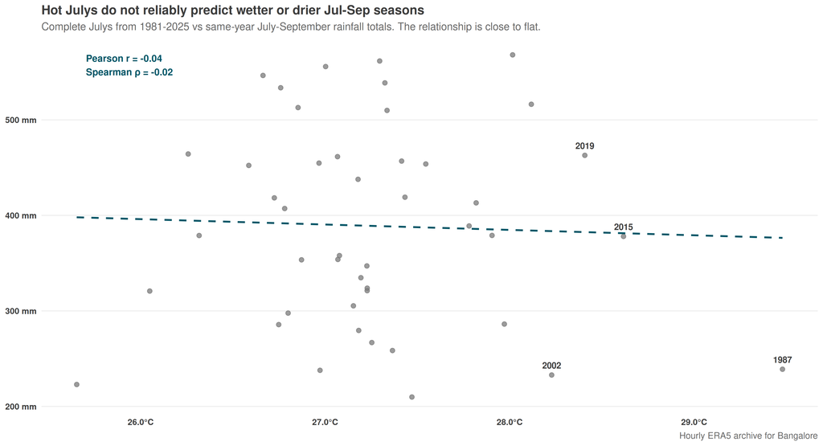

```r
hot_full <- july_full %>% arrange(desc(mean_tmax)) %>% slice(1:4)

p_rain <- ggplot(july_full, aes(mean_tmax, jas_rain_mm)) +
  geom_point(color = "#7a7a7a", size = 2, alpha = 0.75) +
  geom_smooth(method = "lm", se = FALSE, color = "#005566", linewidth = 0.9, linetype = "dashed") +
  geom_text(
    data = hot_full,
    aes(label = year),
    nudge_y = 10,
    size = 3.2,
    fontface = "bold",
    color = "#3C3C3C"
  ) +
  annotate(
    "text",
    x = min(july_full$mean_tmax) + 0.05,
    y = max(july_full$jas_rain_mm),
    hjust = 0,
    vjust = 1,
    label = paste0(
      "Pearson r = ", round(cor_heat_rain, 2),
      "\nSpearman ρ = ", round(spearman_heat_rain, 2)
    ),
    size = 3.5,
    fontface = "bold",
    color = "#005566"
  ) +
  scale_y_continuous(labels = label_number(suffix = " mm")) +
  scale_x_continuous(labels = label_number(accuracy = 0.1, suffix = "°C")) +
  labs(
    title = "Hot Julys do not reliably predict wetter or drier Jul-Sep seasons",
    subtitle = "Complete Julys from 1981-2025 vs same-year July-September rainfall totals. The relationship is close to flat.",
    caption = "Hourly ERA5 archive for Bangalore"
  ) +
  theme_weather_question()

p_rain
```

```r
chart_rain_path <- file.path(chart_dir, "july_hot_rainfall_seasonal_rain.png")
ggsave(chart_rain_path, p_rain, width = 12, height = 6.5, dpi = 180, bg = "white")
```

## Checks

```r
list(
  july_1_15_2026_rank_mean_tmax = current_ytd$rank_mean_tmax,
  july_1_15_2026_rank_max_tmax = current_ytd$rank_max_tmax,
  july_1_15_2026_rank_days_33 = current_ytd$rank_days_33,
  july_1_15_2026_mean_tmax = current_ytd$mean_tmax,
  july_full_heat_rain_pearson = cor_heat_rain,
  july_full_heat_rain_spearman = spearman_heat_rain
)
```

```
## $july_1_15_2026_rank_mean_tmax
## [1] 4
##
## $july_1_15_2026_rank_max_tmax
## [1] 1
##
## $july_1_15_2026_rank_days_33
## [1] 1
##
## $july_1_15_2026_mean_tmax
## [1] 28.772
##
## $july_full_heat_rain_pearson
## [1] -0.03719574
##
## $july_full_heat_rain_spearman
## [1] -0.02450593
```

## Verdict

Insightful: no

The July 1-15 heat is genuinely elevated, but it is not a record on the month-to-date mean maximum temperature scale, and the hotter-end signal is mostly in the single-day peak rather than sustained extreme heat. More importantly, the historical full-July comparison does **not** show a meaningful relationship between hot Julys and Jul-Sep rainfall: the correlation is essentially flat, and the hottest quartile of Julys has about the same seasonal rainfall as the coolest quartile. That makes this a good descriptive check, but not strong enough to publish.

Charts:

- `docs/assets/analysis/july_hot_rainfall_ytd_heat.png`
- `docs/assets/analysis/july_hot_rainfall_seasonal_rain.png`

Blog post:

- not published
- if this ever becomes publishable, create `docs/blog/july-hot-rainfall.html`
- include `This post is AI-written.` at the top of the article body
- end with an `Original question` section containing has July ever been this hot before? and hwat has hot July meant for overall seasonal (jul-sep) rainfall?
- add the post to the top of `docs/blog/index.html` and `docs/blog/feed.xml`
- add `blog_url: "blog/july-hot-rainfall.html"` to the top of `analysis_questions/analyses.yml`